**Contents**

# Explainable AI

## Easy and hard way

In this project I demonstrate two ways to look inside a model and grasp what it looks at when classifying images into classes.

In the easy way, I use DataRobot to predict the type of food from images. DataRobot is an end-to-end enterprise AI platform that automates every step from data to value. It allows to train models for various tasks without writing a single line of code. You can try it for free for a certain amount of computations and after that you need to pay for using the tool.

In the more challenging (and interesting) way, I program a grad-CAM function in python to analyse the [Brain tumor detector](https://kaisuh.github.io/brain-tumor-detector/) -model that I made in another project.

## Grad-CAM visualisation - theory

Gradient-Weighted Class Activation Mapping (Grad-CAM) makes it possible to visualize the regions of the input that contributed towards making prediction by the model. It does so by using the class- specific gradient information flowing into the final convolutional layer of CNN to localize the important regions in the image that resulted in predicting that particular class.

### Steps

- To visualize the activation maps, first the image has to be passed through the model to make the prediction. Using argmax find the index corresponding to the maximum value in the prediction - this is the predicted class.
- Grad-CAM is class specific, and you have to first choose the class $c$.
- Then choose the layer, which feature maps will be analysed $$A^k \epsilon ℝ^{H \times W} $$ where $k=1,...,K$ indexes the channels.
- Next, the gradient that is used to arrive to the predicted class from the feature map activations $A^k$ is calculated. $\alpha^c_k$ represents how important channel $k$ is for class $c$: $$ \alpha^c_k = \frac{1}{Z} \sum_i \sum_j \frac{\partial y^c}{\partial A^k_{ij}}$$ where $$\frac{1}{Z} \sum_i = \text{global average pooling}$$ $$\frac{\partial y^c}{\partial A^k_{ij}} = \text{gradients via backdrop}$$
- To enhance the filter values that resulted in this prediction, the values are multiplied with tensorflow.GradientTape() with the filter values in the last convolutional layer.
- This enhances the filter values that contributed towards making this prediction and lower the filter values that didn't contribute.
- Then, the weighted combination of activation maps is performed and followed by ReLU to obtain the heatmap. $$ L^c_{Grad-CAM}= ReLU(\sum \alpha^c_kA^k) $$ where ReLU keeps only positive evidence, i.e. features that increase the class score, ignoring negative evidence.
- If your goal is to visualise magnitude of influence/sensitivity, instead of support for class $c$, then replasing ReLU with $abs$ can also be helpful visualisation.
- Finally, the feature heatmap is super-imposed on the original image to see the activation locations in the image.

### Intuition

Grad-CAM highlights where the networks is "looking" by weighting conv features according to how much changing them would change the chosen class score. It is not a perfect explanation, just a sensitivity based localiation.What usually happens in the different layers of a image analysis network:

- early layers: edges, color contrasts, simple textures
- mid layers: motifs, parts, curves, repeated patterns
- deep layers: more class relevant patterns like parts of the object or relevant regions

# Part 1. Easy way

In this section, I used DataRobot to build a model to classify images of food into categories. DataRobot has a built in tool to visualise the attention maps and heatmaps for Grad-CAM.

## Food AI

The original dataset from https://www.kaggle.com/vermaavi/food11 consists of 16643 color images belonging to 11 categories. Due to data limitations in DataRobot, I will use pictures from 4 classes only:

1. Dessert
2. Seafood
3. Fried food
4. Vegetable-Fruit

The interface of DataRobot allows you to drop data in and then wrangle it. The system is built in such a way, that you don't need to know programming to train and rank models.

The best performing model for this task was Regularized Logistic Regression (L2).

| Metric | Validation | Cross-validation | Holdout |
| --- | --- | --- | --- |
| AUC | 0.9788 | 0.9877 | 0.9822 |
| Accuracy | 0.8900 | 0.9188 | 0.9036 |
| Balanced Accuracy | 0.8885 | 0.9196 | 0.9045 |
| FVE Multinomial | 0.7699 | 0.8202 | 0.7815 |
| LogLoss | 0.3188 | 0.2475 | 0.3019 |

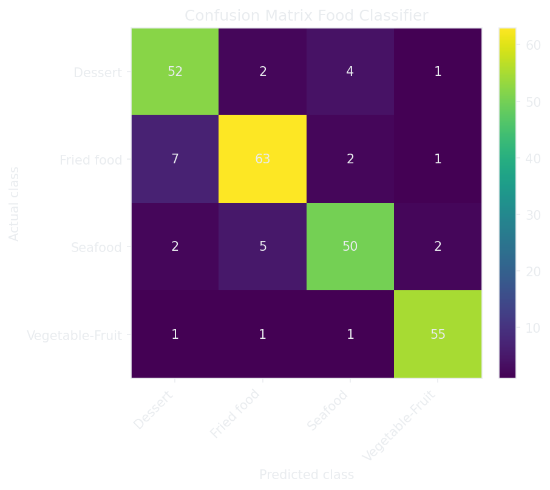

Below is an example from the DataRobot models attention map for the final layer.

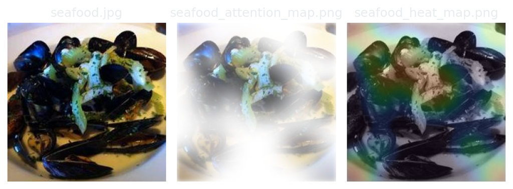

# Part 2. Hard way

Deep learning has proven to be as good and even better than humans in detecting diseases from X-rays, MRI scans and CT scans. It would be interesting to see how the network detects the brain tumors.

Next I will implement my own Grad-CAM pipeline in python. I will apply it on a classifier model I developed. The model takes brain MRI images as input and classifies them into two classes: contains a brain tumor (1) or not (0). You can check the original project here: [Brain tumor detector](https://kaisuh.github.io/brain-tumor-detector/).

## Introduction to the Brain Tumor Detection

This project used a labeled dataset from https://www.kaggle.com/datasets/mateuszbuda/lgg-mri-segmentation. The final pipeline has a two step process where

1. A **Resnet deep learning classifier model** will classify the input images into two groups: tumor detected and tumor not detected.
2. For the images, where tumor was detected, a second step is performed, where a **ResUNet segmentation model** detects the tumor location on the pixel level.

I will be only looking at the gradients from the Resnet classifier model.

Below is an exmaple of an MRI image and the matching mask. This example has a small tumor. In images where no tumor is present, the mask will be completely black.

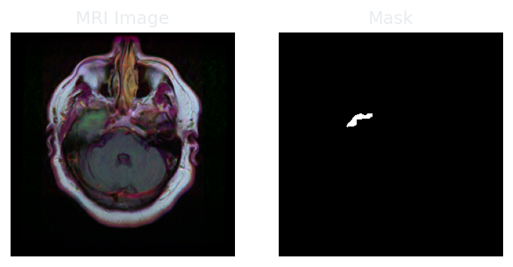

### Theory behind the model

The ResNet architecture involves convolutional neural network layers and "skip connections". You can see the full architecture of the brain tumor detector model at “Representation of different layers and their attention maps”.

#### Convolutional neural networks (CNNs)

- The first CNN layers are used to extract high level general features
- The last couple of layers will perform classification
- Local respective fields scan the image first searching for simple shapes such as edges and lines
- The edges are picked up by the subsequent layer to form more complex features

A good visualisation of the feature extraction with convolutions can be found at https://setosa.io/ev/image-kernels/

#### ResNet (Residual Network)

- As CNNs grow deeper, vanishing gradients negatively imapct the network performance. Vanishing gradient occurs when the gradient is backpropagated to earlier layers which results in a very small gradient.
- ResNets "skip connection" feature can allow training of 152 layers wihtout vanishing gradient problems
- ResNet adds "identity mapping on top of the CNN
- ResNet deep network is trained with ImageNet, which contains 11 million images and 11 000 categories

ResNet paper (He etal, 2015): https://arxiv.org/pdf/1512.03385

The ResNet architectures overcome the training challenges from deep networks compared ot the plain networks. ResNet-152 achieved 3.58% error rate on the ImageNet dataset. This is better than human performance.

## Assessment of the model

```
The model accuracy is 0.94
```

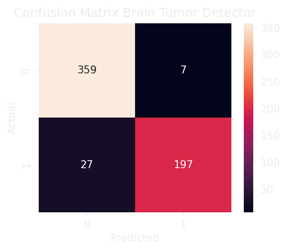

```
Classification report
              precision    recall  f1-score   support

           0       0.93      0.98      0.95       366
           1       0.97      0.88      0.92       224

   micro avg       0.94      0.94      0.94       590
   macro avg       0.95      0.93      0.94       590
weighted avg       0.94      0.94      0.94       590
```

## Grad-CAM for the Brain tumor detector model

I loop over a set of test images (here: cases predicted as containing tumor), loading each MRI slice and its ground-truth mask (if available), and then compute a Grad-CAM attention map for the classifier’s decision. The Grad-CAM attention maps are contrast-enhanced for visibility.

Below are examples of two layers

- conv5_block3_out, which is the last activation layer in the network and
- conv5_block2_out, which is the activation layer after the second convolutional block.

Sometimes the gradients can be very small so you can also see empty images.

To see more examples from different layers, click on the nodes in the model architecture. Jump to “Representation of different layers and their attention maps”.

### Last activation layer

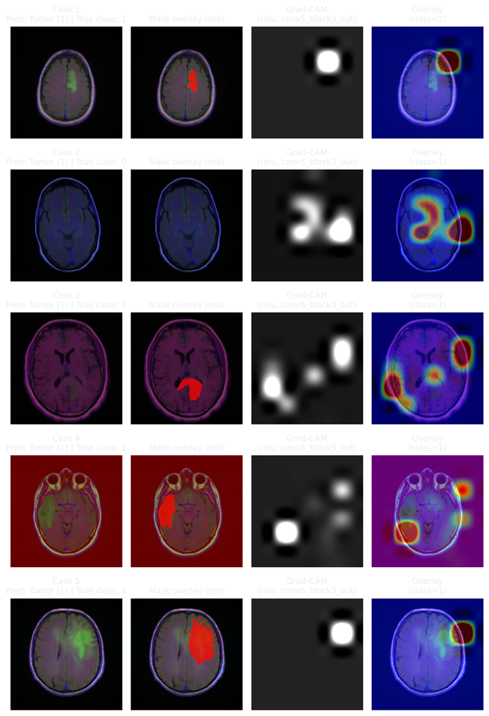

### Second to last activation layer

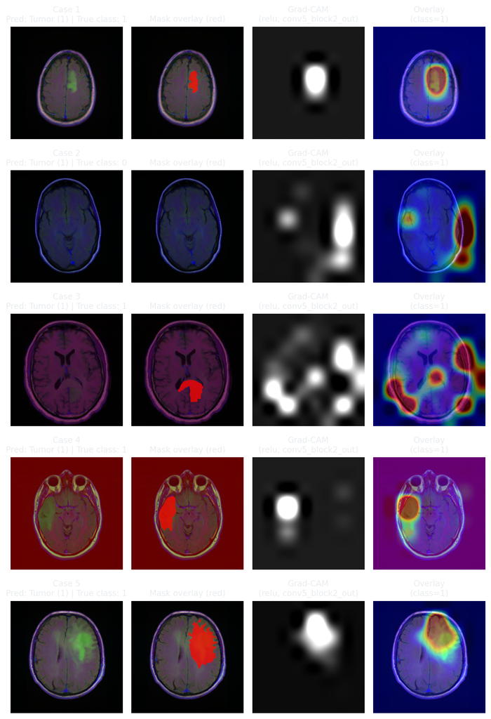

## Representation of different layers and their attention maps

Below is the architecture of the brain tumor detector. By clicking the convolutional layers and activation layers you can see examples of grad-CAM attention maps/heat maps side to side with the actual tumor mask from physicians.

[figure not shown]

[output not shown]

[output not shown]

[figure not shown]